# Wu_Assignment3_Basic text pipeline proficiency

Xingman Wu

2024-11-05

## Load libraries

```r
library(tidyverse)
library(pdftools)
```

```r
#Using pdftools package. Good for basic PDF extraction
text <- pdf_text("../exercises/assets/pdfs/moley_news.PDF")
#pdf_text reads the text from a PDF file.
writeLines(text, "../exercises/assets/extracted_text/moley_news.txt")
#writeLines writes this text to a text file
```

# Split text to separate articles on common identifier

```r
# Step 1: Read the entire text file into R
#For Mac: In Finder, Cntl + click on the filename, NOW hold down Alt/Option, and an item to copy file path will appear as Copy "Filename" as Pathname
file_path <- "../exercises/assets/extracted_text/moley_news.txt"
text_data <- readLines(file_path)

# Step 2: Combine lines into one single string
text_combined <- paste(text_data, collapse = "\n")

# Step 3: Split the text by the "End of Document" phrase
documents <- strsplit(text_combined, "End of Document")[[1]]

# Step 4: Write each section to a new file
output_dir <- "../exercises/assets/extracted_text/"
for (i in seq_along(documents)) {
  output_file <- file.path(output_dir, paste0("moley_news_extracted_", i, ".txt"))
  writeLines(documents[[i]], output_file)
}

cat("Files created:", length(documents), "\n")
```

```
## Files created: 33
```

# Create an index from the first extracted page

```r
moley_index <- read_lines("../exercises/assets/extracted_text/moley_news_extracted_1.txt")
# Extract lines 16 to 172
extracted_lines <- moley_index[16:172]


# Print the extracted lines to the console
cat(extracted_lines, sep = "\n")
```

```
##   1. Loose Ends (134)
##   Jul 14, 2021       Power Line
##
##
##   2. Waiver of provisions of E.O. of Jan. 17, 1873, for Raymond Moley
##   Apr 12, 1933       Primary Sources in U.S. Presidential History           Franklin Delano
##   Roosevelt
##
##
##   3. FDR against the Bill of Rights
##   Jan 05, 2024       ContentEngine Think Tank Newswire English              David Gordon
##
##
##   4. DIED
##   Mar 03, 1975       Newsweek         TRANSITION; Pg. 45
##
##
##   5. Moley, Dr. Jeffrey Fletcher 64
##   Oct 19, 2017       St. Louis Post-Dispatch (Missouri)     CLASSIFIED ADVERTISING
##
##
##   6. KELLE HARBERT WED TO DR. JEFFREY MOLEY
##   Aug 23, 1987       The New York Times Section 1; Part 2, Page 59, Column 5; Society
##   Desk
##
##
##   7. THE NEW DEAL AND RECOVERY, PART 2: INVENTING THE NEW DEAL
##   Jun 22, 2020       States News Service States News Service
##
##
##               | About LexisNexis | Privacy Policy | Terms & Conditions | Copyright © 2020 LexisNexis
##
## 8. Jobs, economic growth dream fading? The present approach of assuming markets will
## grow the economy and jobs is more like a raw deal for citizens
## Feb 26, 2020    Pretoria News (South Africa)/Pretoria News Weekend (South Africa)
##     BUSINESS REPORT; Pg. 18
##
##
## 9. SPEAK SOFTLY AND CARRY A BIG SPEECH; FDR's inaugural address offered hope to a
## nation
```

[output cut: 102 more lines]

```
##
## 29. The Federal Reserves Magic Money
## Nov 14, 2010      Newstex Blogs
##
##
## 30. The New Deal and Recovery, Part 12: Fear Itself
## Apr 14, 2021      Newstex Blogs           George Selgin
##
##
## 31. Victory Speeches
## Nov 07, 2012      The New York Times Blogs        OPINION        ROBERT LEHRMAN
##
##
## 32. The New Deal and Recovery, Part 15: The Keynesian Myth
## Mar 16, 2022      Newstex Blogs           George Selgin
```

```r
extracted_lines <- extracted_lines |>
  as.data.frame()

extracted_lines <- extracted_lines |>
  mutate(extracted_lines = str_remove(extracted_lines, "\\| About LexisNexis \\| Privacy Policy \\| Terms & Conditions \\| Copyright © 2020 LexisNexis"))

extracted_lines
```

```
##                                                                                 extracted_lines
## 1                                                                           1. Loose Ends (134)
## 2                                                                 Jul 14, 2021       Power Line
## 3
## 4
## 5                           2. Waiver of provisions of E.O. of Jan. 17, 1873, for Raymond Moley
## 6     Apr 12, 1933       Primary Sources in U.S. Presidential History           Franklin Delano
## 7                                                                                     Roosevelt
## 8
## 9
## 10                                                            3. FDR against the Bill of Rights
## 11       Jan 05, 2024       ContentEngine Think Tank Newswire English              David Gordon
## 12
## 13
## 14                                                                                      4. DIED
## 15                                       Mar 03, 1975       Newsweek         TRANSITION; Pg. 45
## 16
## 17
## 18                                                            5. Moley, Dr. Jeffrey Fletcher 64
## 19             Oct 19, 2017       St. Louis Post-Dispatch (Missouri)     CLASSIFIED ADVERTISING
## 20
## 21
## 22                                                    6. KELLE HARBERT WED TO DR. JEFFREY MOLEY
## 23          Aug 23, 1987       The New York Times Section 1; Part 2, Page 59, Column 5; Society
## 24                                                                                         Desk
## 25
## 26
## 27                                 7. THE NEW DEAL AND RECOVERY, PART 2: INVENTING THE NEW DEAL
## 28                                   Jun 22, 2020       States News Service States News Service
## 29
## 30
## 31
## 32
## 33         8. Jobs, economic growth dream fading? The present approach of assuming markets will
## 34                               grow the economy and jobs is more like a raw deal for citizens
## 35            Feb 26, 2020    Pretoria News (South Africa)/Pretoria News Weekend (South Africa)
## 36                                                                      BUSINESS REPORT; Pg. 18
## 37
## 38
## 39            9. SPEAK SOFTLY AND CARRY A BIG SPEECH; FDR's inaugural address offered hope to a
```

[output cut: 103 more lines]

```
## 143
## 144                                                        29. The Federal Reserves Magic Money
## 145                                                             Nov 14, 2010      Newstex Blogs
## 146
## 147
## 148                                         30. The New Deal and Recovery, Part 12: Fear Itself
## 149                                     Apr 14, 2021      Newstex Blogs           George Selgin
## 150
## 151
## 152                                                                        31. Victory Speeches
## 153             Nov 07, 2012      The New York Times Blogs        OPINION        ROBERT LEHRMAN
## 154
## 155
## 156                                  32. The New Deal and Recovery, Part 15: The Keynesian Myth
## 157                                     Mar 16, 2022      Newstex Blogs           George Selgin
```

#Build a final dataframe index

```r
# Step 1: Trim spaces and detect rows with titles and dates
cleaned_data <- extracted_lines |>
  mutate(
    # Trim leading and trailing spaces before detection
    trimmed_line = str_trim(extracted_lines),

    # Detect titles (start with a number and a period)
    is_title = str_detect(trimmed_line, "^\\d+\\. "),

    # Detect dates (e.g., "Aug 14, 2024")
    is_date = str_detect(trimmed_line, "\\b\\w{3} \\d{1,2}, \\d{4}\\b")
  )

# Step 2: Shift dates to align with corresponding titles
aligned_data <- cleaned_data |>
  mutate(
    date = ifelse(lead(is_date, 1), lead(trimmed_line, 1), NA_character_)  # Shift date to title's row
  ) |>
  filter(is_title) |>
  select(trimmed_line, date)  # Keep only the relevant columns

# Step 3: Rename columns for clarity
final_data <- aligned_data |>
  rename(
    title = trimmed_line,
    date = date
  )

#Step 4: Date and Publication in separate columns, and formatted
final_data <- separate(data = final_data, col = date, into = c("date2", "publication"), sep = "  ", extra = "merge", fill = "right")


#Step 5: Format date, clean headline
final_data <- final_data |>
  mutate(date = as.Date(date2,format = "%b %d, %Y")) |>
  mutate(title =str_remove(title, "^\\d+\\. ")) |>
  subset(select = -(date2)) |>
  mutate(index = row_number()) |>
  select(index, date, title, publication)
View(final_data)

#write_csv(final_data, "assets/moley.csv")
```

# Raw text compiler

###Fix Article 1 to remove the index

```r
article1 <- read_lines("../exercises/assets/extracted_text/moley_news_extracted_1.txt")
article1
```

```
##   [1] "User Name: ="
##   [2] "Date and Time: = 2024-11-04"
##   [3] "Job Number: = 237727801"
##   [4] ""
##   [5] ""
##   [6] ""
##   [7] "Documents (32)"
##   [8] ""
##   [9] "  Client/Matter: -None-"
##  [10] "  Search Terms: atleast3(Moley) and \"Raymond Moley\""
##  [11] "  Search Type: Boolean"
##  [12] "  Content Type                        Narrowed by"
##  [13] "  news                                -None-"
##  [14] ""
##  [15] ""
```

[output cut: 231 more lines]

```r
article1_cleaned <- article1[179:243]

writeLines(article1_cleaned, "../exercises/assets/extracted_text/moley_news_extracted_1.txt")
```

#Text compiler

```r
###
# Define function to loop through each text file
###

create_article_text <- function(row_value) {

  #row_value is the single argument that is passed to the function
  # Take each row of the dataframe
  temp <- final_index %>%
    slice(row_value)

  # Store the filename for  use in constructing articles dataframe
  temp_filename <- temp$filename

  # Create a dataframe by reading in lines of a given textfile
  # Add a filename column
  articles_df_temp <- read_lines(temp$filepath) %>%
    as_tibble() %>%
    mutate(filename = temp_filename)

  # Bind results to master articles_df
  # <<- returns to global environment
  articles_df <<- articles_df %>%
    bind_rows(articles_df_temp)
}

###
# Create elements needed to run function
###

# Create empty tibble to store results
articles_df <- tibble()
#running once to test
#create_article_text(2)
# Create an array of numbers to loop through, from 1 to the number of rows in our index dataframe
row_values <- 1:nrow(final_index)

###
# Execute function using lapply
# This loops through each row of the dataframe and append results to master file
###

lapply(row_values, create_article_text)
```

```
## [[1]]
## # A tibble: 65 × 2
##    value                                                                filename
##    <chr>                                                                <chr>
##  1 "                                                                  … moley_n…
##  2 "                                                  Loose Ends (134)" moley_n…
##  3 ""                                                                   moley_n…
##  4 ""                                                                   moley_n…
##  5 ""                                                                   moley_n…
##  6 ""                                                                   moley_n…
##  7 "                                                Loose Ends (134)"   moley_n…
##  8 "                                                    Power Line"     moley_n…
##  9 "                                                   July 14, 2021"   moley_n…
## 10 ""                                                                   moley_n…
## # ℹ 55 more rows
##
## [[2]]
## # A tibble: 151 × 2
##    value                                                                filename
##    <chr>                                                                <chr>
##  1 "                                                                  … moley_n…
##  2 "                                                  Loose Ends (134)" moley_n…
##  3 ""                                                                   moley_n…
##  4 ""                                                                   moley_n…
##  5 ""                                                                   moley_n…
##  6 ""                                                                   moley_n…
##  7 "                                                Loose Ends (134)"   moley_n…
##  8 "                                                    Power Line"     moley_n…
##  9 "                                                   July 14, 2021"   moley_n…
## 10 ""                                                                   moley_n…
## # ℹ 141 more rows
##
## [[3]]
## # A tibble: 287 × 2
##    value                                                                filename
##    <chr>                                                                <chr>
##  1 "                                                                  … moley_n…
##  2 "                                                  Loose Ends (134)" moley_n…
##  3 ""                                                                   moley_n…
##  4 ""                                                                   moley_n…
```

[output cut: 456 more lines]

```
## [[32]]
## # A tibble: 6,348 × 2
##    value                                                                filename
##    <chr>                                                                <chr>
##  1 "                                                                  … moley_n…
##  2 "                                                  Loose Ends (134)" moley_n…
##  3 ""                                                                   moley_n…
##  4 ""                                                                   moley_n…
##  5 ""                                                                   moley_n…
##  6 ""                                                                   moley_n…
##  7 "                                                Loose Ends (134)"   moley_n…
##  8 "                                                    Power Line"     moley_n…
##  9 "                                                   July 14, 2021"   moley_n…
## 10 ""                                                                   moley_n…
## # ℹ 6,338 more rows
```

```r
###
# Clean up articles_df and join to index dataframe
###

articles_df <- articles_df %>%
  select(filename, sentence=value) %>%
  inner_join(final_index)
View(articles_df)
#After viewing articles_df, I see the first line from the index that I don't need. Cutting it

articles_df <- articles_df %>%
  slice(-1) |>
  #gets rid of blank rows
    filter(trimws(sentence) != "") %>%
  slice(-1)

write.csv(articles_df, "../exercises/assets/extracted_text/moley.csv")
# Now we get the data frame with one row per sentence
```

#Then tokenize the data, one word per row Clean the data

```r
library(tidyverse)
library(tidytext)
library(janitor)
library(lubridate)
library(jsonlite)
library(rio)
library(quanteda)
articles_df <- articles_df %>% mutate(text = str_squish(sentence))
articles_df <- articles_df %>%
  mutate(text = tolower(text)) |>
  mutate(text = str_replace_all(text, "wiki|enwikipediaorg|load-date|news service|publication-type|publication type|the new york times|www.alt-m.org|length:|language: english|all rights reserved|Length|words|title|pages|publication date|publication subject|issn|language of publication: english|document url|copyright|last updated|database|startofarticle|proquest document id|classification|https|--|people|publication info|illustration|caption|[0-9.]|identifier /keyword|twitter\\.", ""))

data_use <- str_replace_all(articles_df$text, "- ", "")
data_tok <- tibble(data_use,)
head(data_tok) # The name of the column is data_use
```

```
## # A tibble: 6 × 1
##   data_use
##   <chr>
## 1 "loose ends ()"
## 2 "power line"
## 3 "july , "
## 4 "  power line "
## 5 "  "
## 6 "dateline: new delhi, -::"
```

```r
# create bigram
data_tok_bi <- data_tok  %>%
  unnest_tokens(bigram, data_use, token="ngrams", n=2)
#View(data_tok_bi)

data_tok_bi_count <- data_tok_bi %>%
  separate(bigram, c("word1", "word2"), sep = " ")%>% # Seperate the words
  filter(!word1 %in% stop_words$word) %>%
  filter(!word2 %in% stop_words$word) %>% # remove stopwords
  filter(!is.na(word1)) %>%
  filter(!is.na(word2)) %>%  # remove NAs
  count(word1, word2, sort = TRUE)
data_tok_bi_count
```

```
## # A tibble: 7,334 × 3
##    word1     word2          n
##    <chr>     <chr>      <int>
##  1 gold      standard      46
##  2 white     house         46
##  3 raymond   moley         40
##  4 inaugural address       28
##  5 keynesian myth          28
##  6 columbia  university    24
##  7 brain     trust         15
##  8 south     africa        15
##  9 deal      policies      14
## 10 economic  recovery      13
## # ℹ 7,324 more rows
```

```r
# top 20 bigrams
data_tok_bi_count_20  <- data_tok_bi_count  %>%
  slice_max(n, n=20)
data_tok_bi_count_20
```

```
## # A tibble: 25 × 3
##    word1     word2          n
##    <chr>     <chr>      <int>
##  1 gold      standard      46
##  2 white     house         46
##  3 raymond   moley         40
##  4 inaugural address       28
##  5 keynesian myth          28
##  6 columbia  university    24
##  7 brain     trust         15
##  8 south     africa        15
##  9 deal      policies      14
## 10 economic  recovery      13
## # ℹ 15 more rows
```

```r
library(ggplot2)
library(forcats)

# combine the "word1" and "word2" into one column, and create a new data frame
plot_bi <- data.frame(word= paste(data_tok_bi_count_20$word1, data_tok_bi_count_20$word2), n = data_tok_bi_count_20$n)
head(plot_bi)
```

```
##                  word  n
## 1       gold standard 46
## 2         white house 46
## 3       raymond moley 40
## 4   inaugural address 28
## 5      keynesian myth 28
## 6 columbia university 24
```

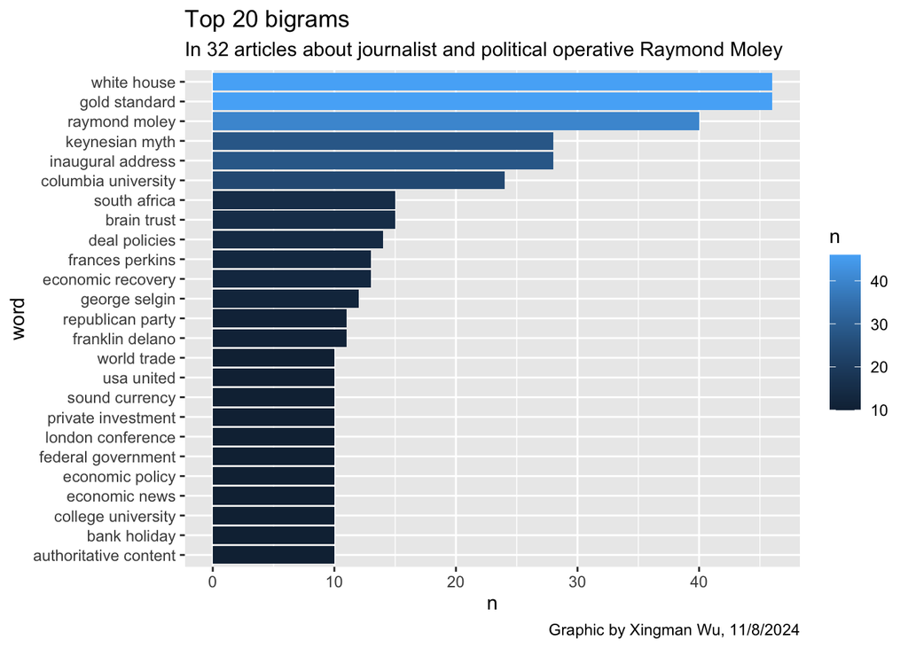

```r
View(plot_bi)

plot_bi  %>%
  ggplot(aes(n, fct_reorder(word, n, .desc = F), fill = n)) +
  geom_col() +
  labs(y = NULL) +
   labs(title = "Top 20 bigrams",
       subtitle = "In 32 articles about journalist and political operative Raymond Moley",
       caption = "Graphic by Xingman Wu, 11/8/2024",
       y="word",
       x="n")
```

#At the bottom of the R markdown document, write a 300 word memo describing your key findings.

There are 32 articles in total. After running the bigram analysis, I found that these 32 articles are centered around Raymond Moley and the New Deal period. Moley, a close advisor to FDR, played a big role in creating the early New Deal ideas and FDR’s famous inaugural speech, which aimed to lift people’s spirits during the Great Depression. However, Moley later became critical, feeling the New Deal went too far with changes like moving away from the gold standard, which allowed more flexible spending. This shift in economic policy, often seen as “Keynesian” (after economist John Maynard Keynes), was debated for its effectiveness. The New Deal’s policies, like bank holidays to stabilize banks, showed how the government was now deeply involved in helping the economy, which some people supported and others found too controlling. Figures like Labor Secretary Frances Perkins helped advance workers’ rights, while universities, especially Moley’s Columbia, influenced and critiqued these policies. The impact reached globally, with countries like South Africa looking at the New Deal as an example during their own struggles. In the end, the New Deal was about the federal government taking bold action to try to fix the economy, even though some felt it overstepped, and its success remains a topic of debate.